# Text Similarity

Introduction to Text as Data

Amber Boydstun & Cory Struthers

April 27-29, 2023

### Introduction

There are a number of approaches to text similarity, but we’ll focus pairwise comparisons. “Pairwise” means that the terms of each document in the corpus are compared to the terms of every other document in the corpus. Pairwise comparison is a “bag of words” approach, meaning the frequency of terms influence the output but the order of the terms do not.

We will need the following packages:

```r
library(quanteda)
library(quanteda.textstats)
library(tidyverse)
library(ggplot2)
library(ggdendro)
library(comperes)
library(readxl)
library(igraph)
library(tidytext)

options("scipen"=100, "digits"=4)

# Set working directory
setwd("/Users/cs86487/Dropbox/text-as-data-JUST-CORY-AND-AMBER/modules/data/")
getwd() # view working directory
```

```
## [1] "/Users/cs86487/Dropbox/text-as-data-JUST-CORY-AND-AMBER/modules/data"
```

Most text similarity methods are vector space models, which use linear algebra to more directly leverage word counts to represent meaningful differences (or lack thereof) between two or more texts. Unlike dictionary methods, which count and emphasize terms the researcher designates, text similarity uses *all terms* in a vector (i.e., the document converted to a row in a dfm) to evaluate similarity – ignoring the latent concept driving the frequent or infrequent use of equivelent terms. For this reason, crafting the dfm carefully in the pre-processing stage is essential.

`quanteda` offers two functions related to text (dis)similarity. Both return a *D* x *D* symmetrical matrix, where *D* is equal to the number of documents (however grouped) in the corpus, and each cell represents the similarity or distance between two text vectors.

Let’s begin with a toy example, completing pre-processing steps as usual. Note that removing stopwords are particularly important in text similarity approaches because stopwords will drive similarity between texts despite being conceptually meaningless.

```r
# Toy example
energy = c(position1 = "We must adapt our energy infrastructure to climate change.",
            position2 = "Low income people are harmed by renewable energy commitments.",
            position3 = "Health and climate benefits are core factors in determining energy policy.",
            position4 = "Energy policy should prioritize keeping electricty prices low for people.")

# Construct dfm
energy_dfm = corpus(energy) %>%
    quanteda::tokens(remove_punct = TRUE) %>% # specify quanteda because tidytext loaded
    tokens_remove(stopwords("en"))  %>%
    tokens_wordstem() %>%
    dfm()
energy_dfm
```

```
## Document-feature matrix of: 4 documents, 22 features (67.05% sparse) and 0 docvars.
##            features
## docs        must adapt energi infrastructur climat chang low incom peopl harm
##   position1    1     1      1             1      1     1   0     0     0    0
##   position2    0     0      1             0      0     0   1     1     1    1
##   position3    0     0      1             0      1     0   0     0     0    0
##   position4    0     0      1             0      0     0   1     0     1    0
## [ reached max_nfeat ... 12 more features ]
```

### Apply Euclidean distance

The Euclidean distance between two vectors, *a* and *b*, is calculated as:

$\boldsymbol{a} - \boldsymbol{b} = \sqrt{(\sum^n_1{(a_i-b_i)^2}}$

Euclidean distance ranges from 0 to values greater than 1. Larger values indicate greater distance, or less similarity, while smaller values mean less distance, or greater similarity. Below, we apply the calculation from the `textstat_dist` function. `textstat_dist` calcualtes the *distance* between two vectors, applying `euclidean`, `Chisquared`, `minkowski`, or other methods as options the researcher specifies. `euclidean` is the most common and the default method for `textstat_dist()`.

After applying `textstat_dist`, we’ll calculate pairwise comparisons “by hand” to improve our understanding of this pairwise approach.

```r
# Euclidean distance quanteda function
energy_dist = textstat_dist(energy_dfm , method = "euclidean") # default
print(energy_dist)
```

```
## textstat_dist object; method = "euclidean"
##           position1 position2 position3 position4
## position1         0      3.32      3.16      3.46
## position2      3.32         0      3.61      3.00
## position3      3.16      3.61         0      3.46
## position4      3.46      3.00      3.46         0
```

```r
# First, reshape dfm object so columns are each text and rows are features
energy_dfm_reshaped = tidy(energy_dfm) %>% # using tidytext
  cast_dfm(term, document, count)  %>% # using tidytext
  convert("data.frame")

# Euclidean distance calculation
euclidean_dist = function(a,b) sqrt(sum((a - b)^2))

# Apply to lowest and highest observed distances
euclidean_dist(energy_dfm_reshaped$position2, energy_dfm_reshaped$position4) # least distant (lowest value)
```

```
## [1] 3
```

```r
euclidean_dist(energy_dfm_reshaped$position2, energy_dfm_reshaped$position3) # most distant (highest value)
```

```
## [1] 3.606
```

The output suggests position2 and position3 are most distant from one another (3.61), whereas position2 and position4 are the least distant to one another (3.00).

**Question 1. Based on the text, do you agree with this assessment or other calculated values based on the text? Why or why not?**

### Apply cosine similarity

Now let’s do apply cosine similarity using `textstat_simil`. The cosine similarity of two vectors, A and B, is calculated as:

Cosine similarity = $\frac{ \boldsymbol{a}}{|| \boldsymbol{a}||}.\frac{ \boldsymbol{b}}{|| \boldsymbol{b}||} = \frac{\sum_ia_ib_i}{(\sqrt{\sum_ia^2_i}(\sqrt{\sum_ib^2_i}}$

Cosine similarity scores range from 0 to 1 for word frequencies. The inverse of Euclidean distance, larger values in cosine similarity indicate greater similarity, or less distance, while smaller values mean less similarly, or greater distance. Methods options for `textstat_simil` include `cosine`, `correlation`, `jaccard`, among others. `cosine` is the default and currently the most popular.

```r
# Cosine similarity quanteda function
energy_simil = textstat_simil(energy_dfm, method="cosine")
print(energy_simil)
```

```
## textstat_simil object; method = "cosine"
##           position1 position2 position3 position4
## position1     1.000     0.154     0.289     0.144
## position2     0.154     1.000     0.134     0.401
## position3     0.289     0.134     1.000     0.250
## position4     0.144     0.401     0.250     1.000
```

```r
# Cosine similarly calculation
cosine_sim = function(a, b) {
  return(sum(a*b)/sqrt(sum(a^2)*sum(b^2)) )
}

# Again, using reshaped dfm
cosine_sim(energy_dfm_reshaped$position2, energy_dfm_reshaped$position4)
```

```
## [1] 0.4009
```

```r
cosine_sim(energy_dfm_reshaped$position2, energy_dfm_reshaped$position3)
```

```
## [1] 0.1336
```

This output suggests position2 and position3 are least similar (0.134), whereas position2 and position4 are most similar (0.401). Aha! The two approaches produce nearly equivalent results, but mirroring one another. Reviewing the texts in our toy example, we might imagine that a researcher has asked respondents to describe their position on energy policy in an open-ended survey question. In addition to understanding the latent dimensions people care about in regards to this policy domain, the researcher might hypothesize that respondents with similar attributes (ideology, class) offer similar responses. This point brings us back again to grouping and nestedness in our data, which we’ll revisit shortly.

One reason cosine similarity is often used over Euclidean distance for larger corpora is the former normalizes for magnitude, or document length, by comparing the angle of the vectors. Let’s experiment with our toy example to see what happens when we make position4 a much longer document.

```r
# Experimental example
energy_exp = c(position1 = "We must adapt our energy infrastructure to climate change.",
            position2 = "Low income people are harmed by renewable energy commitments.",
            position3 = "Health and climate benefits are core factors in determining energy policy.",
            position4 = "Energy policy should prioritize keeping electricty prices low for people. The rest of this text is substantively meaningless. Let's see what happens to our measures when we have a really long document compared to the rest of the documents.")

# Construct dfm
exp_dfm = corpus(energy_exp) %>%
    quanteda::tokens(remove_punct = TRUE) %>%
    tokens_remove(stopwords("en"))  %>%
    tokens_wordstem() %>%
    dfm()

# Apply Euclidean distance
exp_dist = textstat_dist(exp_dfm, method = "euclidean")
print(exp_dist)
```

```
## textstat_dist object; method = "euclidean"
##           position1 position2 position3 position4
## position1         0      3.32      3.16      5.39
## position2      3.32         0      3.61      5.10
## position3      3.16      3.61         0      5.39
## position4      5.39      5.10      5.39         0
```

Let’s try cosine similarity, which normalizes for document length.

```r
# Apply cosine similarity
exp_simil = textstat_simil(exp_dfm, method="cosine")
print(exp_simil)
```

```
## textstat_simil object; method = "cosine"
##           position1 position2 position3 position4
## position1    1.0000     0.154     0.289    0.0816
## position2    0.1543     1.000     0.134    0.2268
## position3    0.2887     0.134     1.000    0.1414
## position4    0.0816     0.227     0.141    1.0000
```

### Visualization through hierarchical clustering

Now let’s try each of these tools on a larger corpus. Like always, we first tokenize and convert the text to a document-feature matrix. Below, we use the news corpus, first applying collocation analysis to identify common capitalized bi- and tri-grams, and then adding them to the tokens object.

Importantly, and depending on the research question and data, TF-IDF weights are appropriate or preferred to unweighted term counts in the DFM. For simplicity, we stick with unweighted term counts in our example.

```r
# load news corpus
news_corp = readRDS("news_corp.RDS")

# Create tokens object
news_toks = news_corp %>%
    quanteda::tokens(remove_punct = TRUE,
           remove_numbers = TRUE,
           remove_symbols = TRUE) %>%
  tokens_remove(stopwords("en")) # remove stopwords in tokens

# Identify capitalized collocations
news_cols = tokens_select(news_toks, pattern = "^[A-Z]",
                                valuetype = "regex",
                                case_insensitive = FALSE) %>%
                  textstat_collocations(min_count = 10, size=2:3) # specify size
View(news_cols)

# Incorporate collocations into dfm toks
news_dfm =  tokens_compound(news_toks, news_cols, concatenator = " ") %>%
    tokens_wordstem ()%>% # stem words after adding collocations
    dfm(tolower = TRUE)  %>%
    dfm_trim(min_termfreq = 10, min_docfreq = 10)

# Observe collocations ("united st")
textstat_frequency(news_dfm) %>%
  head(50)
```

|  | feature | frequency | rank | docfreq | group |
| --- | --- | --- | --- | --- | --- |
| 1 | said | 1667 | 1 | 665 | all |
| 2 | immigr | 1023 | 2 | 310 | all |
| 3 | state | 853 | 3 | 411 | all |
| 4 | year | 753 | 4 | 466 | all |
| 5 | gun | 636 | 5 | 141 | all |
| 6 | law | 603 | 6 | 317 | all |
| 7 | smoke | 558 | 7 | 146 | all |
| 8 | one | 541 | 8 | 384 | all |
| 9 | new | 507 | 9 | 329 | all |
| 10 | peopl | 494 | 10 | 339 | all |

[output cut: 40 more lines]

Conceivably, we might be interested in whether stories produced by similar outlets utilize more or less similar terms. We can group our dfm by “Source” to explore support for this premise. Like we’ve done in prior modules, we can group the dfm by source and then use `textstat_dist` to first compare the pairwise euclidean distance of the 14 sources in our corpus.

`quanteda` offers an option for easy and useful visualization of distance scores, particularly when grouped. After grouping the dfm and calculating euclidean distance across all pairs, we can visualize similarity scores across texts by different news sources using `hclust`, which is part of base R. `hclust` conducts hierarchical cluster analysis on the (dis)similiarities of the objects (in our case, texts by different media sources). As shown below, we add the `dist` function to convert the object to an object compatible with `hclust` to create the dendogram.

```r
# Group dfm by news Source
news_dfm_sources = dfm_group(news_dfm, groups = Source)
ndoc(news_dfm_sources) # 14 groups
```

```
## [1] 14
```

```r
# Euclidean distance quanteda function
news_dist = as.dist(textstat_dist(news_dfm_sources, method = "euclidean"))
print(news_dist)
```

```
##                          atlanta journal and constitution daily news
## daily news                                          242.0
## denver post                                         245.4      163.8
## herald-sun                                          276.8      202.2
## new york times                                      602.4      679.8
## palm beach post                                     285.6      183.7
## philadelphia inquirer                               227.1      185.8
## saint paul pioneer press                            235.3      169.5
## san jose mercury news                               222.8      233.9
## st. louis post-dispatch                             225.9      225.7
## st. petersburg times                                287.1      184.7
## tampa bay times                                     366.6      241.8
## usa today                                           261.3      177.7
## washington post                                     600.8      686.7
##                          denver post herald-sun new york times palm beach post
## daily news
## denver post
## herald-sun                     168.0
## new york times                 698.1      742.9
## palm beach post                158.7      157.7          737.3
## philadelphia inquirer          188.1      215.7          639.4           200.8
## saint paul pioneer press       155.0      176.8          672.0           178.2
## san jose mercury news          240.4      288.4          569.0           278.1
## st. louis post-dispatch        241.0      286.4          591.7           270.0
## st. petersburg times           159.7      160.7          741.1           125.5
## tampa bay times                211.8      176.6          838.0           155.8
## usa today                      171.3      181.5          700.2           160.6
## washington post                707.7      762.4          385.4           751.8
##                          philadelphia inquirer saint paul pioneer press
## daily news
## denver post
## herald-sun
## new york times
## palm beach post
## philadelphia inquirer
## saint paul pioneer press                 170.7
## san jose mercury news                    218.6                    222.6
## st. louis post-dispatch                  210.3                    220.5
## st. petersburg times                     219.8                    185.0
## tampa bay times                          286.2                    242.7
```

[output cut: 15 more lines]

```
## washington post                          563.3                   580.0
##                          st. petersburg times tampa bay times usa today
## daily news
## denver post
## herald-sun
## new york times
## palm beach post
## philadelphia inquirer
## saint paul pioneer press
## san jose mercury news
## st. louis post-dispatch
## st. petersburg times
## tampa bay times                         148.5
## usa today                               165.2           205.9
## washington post                         756.9           856.5     709.0
```

```r
# Apply cluster analysis
news_source_clust = hclust(news_dist)
```

`ggdendrogram` in the `ggdendro` package will plot clusters from the `textstat_dist` matrix. A dendrogram is a tree diagram representing clustered observations, where “leaves” (the vertical, terminal lines) are nested in a branch (or clade, the horizontal lines). Both branches (the sub-organizational structure) and leaves (the magnitude) provide visual aid to clustering tendencies in the data. Separate branches indicate distinct clusters, and – for dissimilarity score – the higher the branch, the more dissimiliar the clusters. Likewise, the taller the leaves, the more dissimilar the scores among that clustered group.

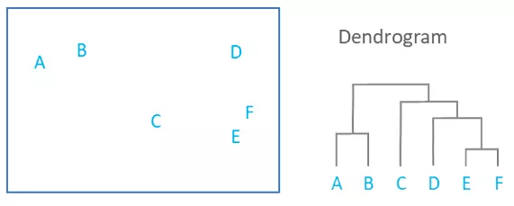

Note that the left-right orientation is irrelevant and that dendrograms cannot tell us how many clusters exist in the data.

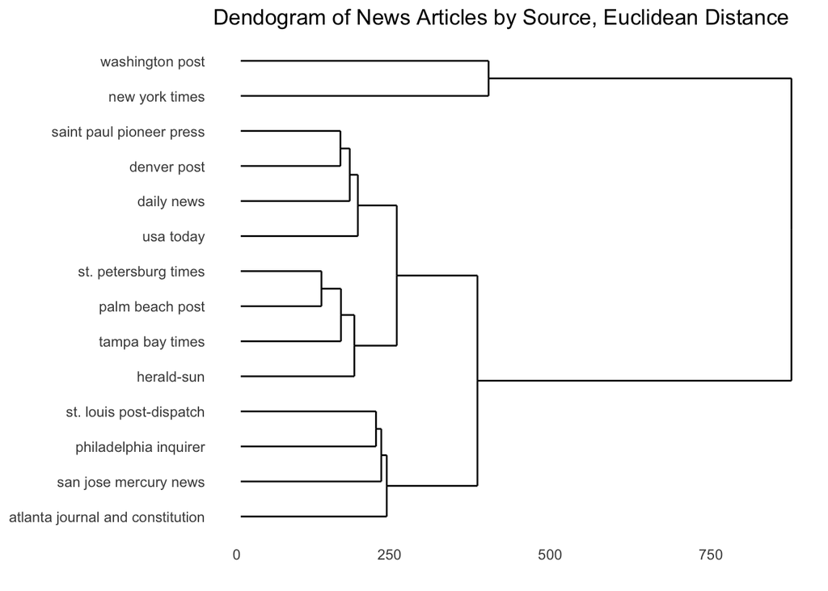

```r
# Plot dendrogram
ggdendrogram(news_source_clust, rotate = TRUE) +
  labs( xlab="Distance", title="Dendogram of News Articles by Source, Euclidean Distance")
```

The dendrogram suggests (but does not confirm) that articles produced by two major national news outlets, New York Times and Washington Post, are a distinct cluster – uniquely different from all other news sources. But the *height of the leaves* suggest they are not the most similar to one another, compared to all other clsuters. Articles produced by news outlets in the same geographic region – the Tampa Bay Times, Palm Beach Post, and St. Petersburg Times (all in Florida) – not only cluster together, but have much greater similarity to one another (as indicated by shorter leaves). Geographic clustering may be driven by stories that focus on the state or region.

Although top features do not paint the full picture, they can give us some intuition of the terms driving distance (or similarity) among units. Let’s plot the top 15 terms by source.

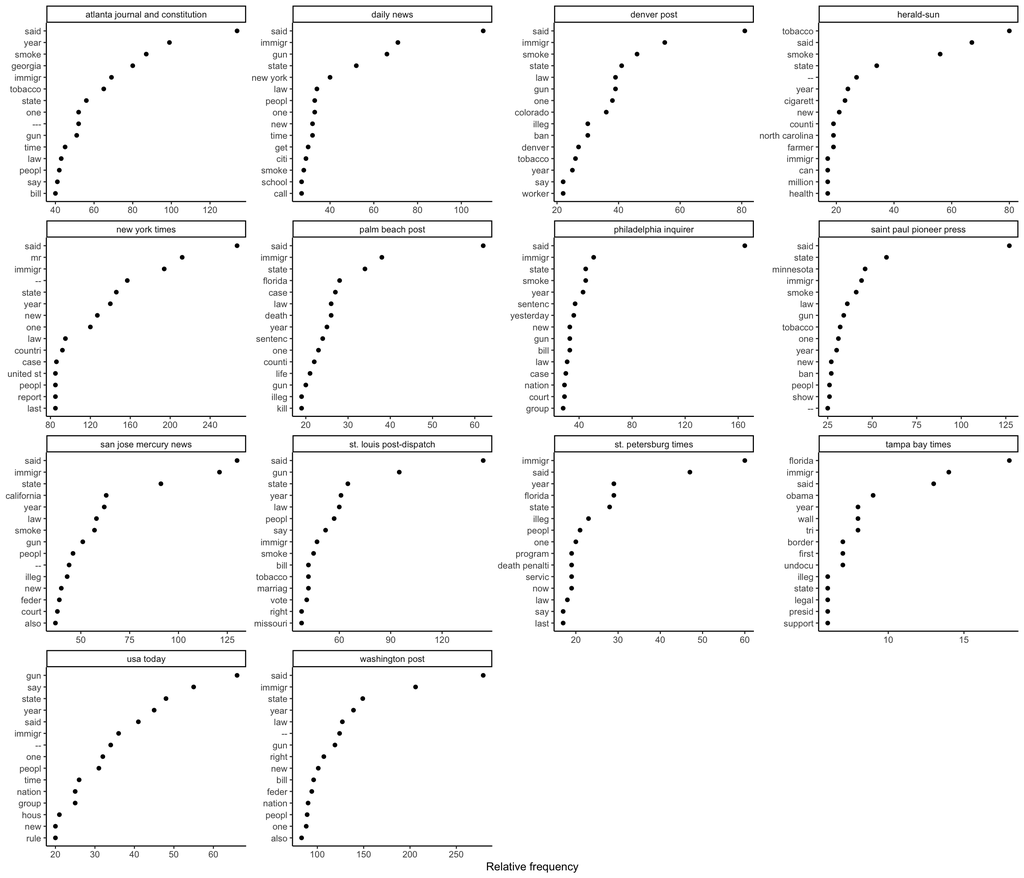

```r
# Sort by reverse frequency order
freq_sources = textstat_frequency(news_dfm_sources, n = 15,
                                  groups = news_dfm_sources$Source)

# Plot
ggplot(data = freq_sources , aes(x = nrow(freq_sources):1, y = frequency)) +
     geom_point() +
     theme(text = element_text(size=24)) +
     facet_wrap(~ group, scales = "free") +
     coord_flip() +
     theme_classic() +
     scale_x_continuous(breaks = nrow(freq_sources):1,
                        labels = freq_sources$feature) +
     labs(x = NULL, y = "Relative frequency")
```

As we suspected, geographic mentions may be influencing clustering among geographic news outlets. Exploring top features may also force us to ask ourselves important questions about the data. For example, what bias might we be introducing by examining similarities by source but across all topics? We’ll turn to that question at the end of the module.

Now let’s try applying cosine similarity to the corpus. A common practice among researchers is to convert cosine similarity scores to “cosine dissimilarity”, which can be done by subtracting the cosine similarity scores from 1. We’ll do that below in order to compare our two dendrograms using the `apply` function on the matrix object, then converting back to `dist` and `hclust`.

Apply functions are a family of functions in base R, which allow us to perform actions on many chunks of data. An apply function is a loop, but it runs faster than loops and often with less code. And, there are different apply() functions.

Note that the `dist` function does not change the values in the output, but makes the object compatible with `hclust`.

```r
# Cosine similarity quanteda function
news_source_cos_sim = as.dist(textstat_simil(news_dfm_sources, method = "cosine", margin="documents"))
print(news_source_cos_sim)
```

```
##                          atlanta journal and constitution daily news
## daily news                                         0.7990
## denver post                                        0.8110     0.7963
## herald-sun                                         0.7616     0.6595
## new york times                                     0.7987     0.7828
## palm beach post                                    0.7475     0.7301
## philadelphia inquirer                              0.8182     0.8065
## saint paul pioneer press                           0.8144     0.7995
## san jose mercury news                              0.8422     0.8234
## st. louis post-dispatch                            0.8341     0.8269
## st. petersburg times                               0.7499     0.7280
## tampa bay times                                    0.5547     0.5501
## usa today                                          0.7742     0.7549
## washington post                                    0.8357     0.8227
##                          denver post herald-sun new york times palm beach post
## daily news
## denver post
## herald-sun                    0.7130
## new york times                0.7864     0.7119
## palm beach post               0.7424     0.6509         0.7735
## philadelphia inquirer         0.8008     0.7334         0.8160          0.7974
## saint paul pioneer press      0.8177     0.7506         0.8064          0.7488
## san jose mercury news         0.8320     0.7312         0.8519          0.7899
## st. louis post-dispatch       0.8119     0.7098         0.8220          0.7905
## st. petersburg times          0.7383     0.6287         0.7725          0.7546
## tampa bay times               0.5413     0.4515         0.5749          0.5843
## usa today                     0.7297     0.6433         0.7971          0.7164
## washington post               0.8246     0.7183         0.9042          0.8043
##                          philadelphia inquirer saint paul pioneer press
## daily news
## denver post
## herald-sun
## new york times
## palm beach post
## philadelphia inquirer
## saint paul pioneer press                0.8386
## san jose mercury news                   0.8376                   0.8479
## st. louis post-dispatch                 0.8426                   0.8383
## st. petersburg times                    0.7319                   0.7252
## tampa bay times                         0.5512                   0.5290
```

[output cut: 15 more lines]

```
## washington post                         0.8935                  0.8761
##                          st. petersburg times tampa bay times usa today
## daily news
## denver post
## herald-sun
## new york times
## palm beach post
## philadelphia inquirer
## saint paul pioneer press
## san jose mercury news
## st. louis post-dispatch
## st. petersburg times
## tampa bay times                        0.6176
## usa today                              0.6959          0.5111
## washington post                        0.7980          0.6238    0.8397
```

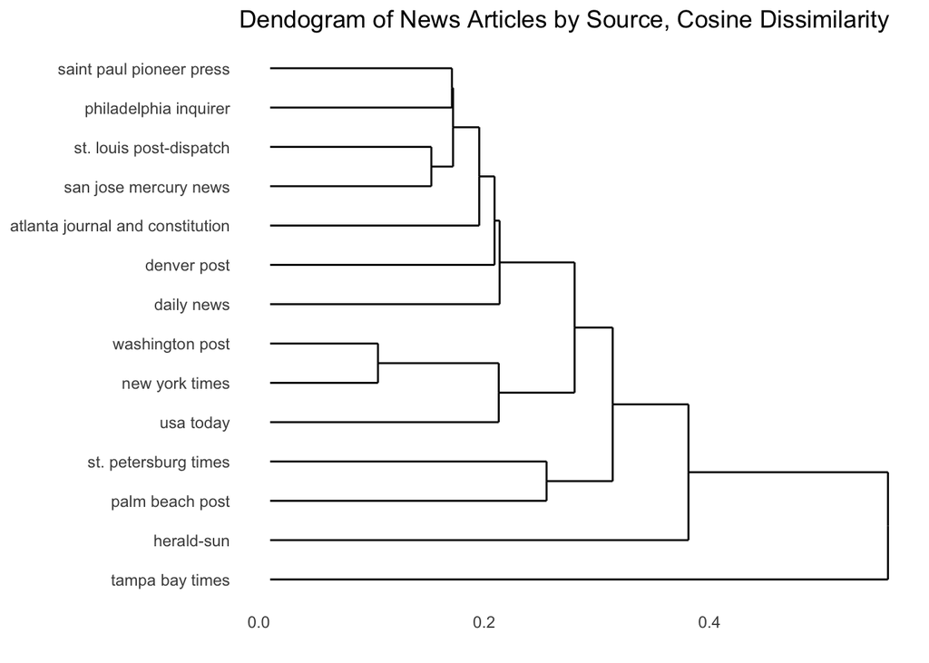

```r
# Create matrix to transform
news_source_cos_sim = as.matrix(news_source_cos_sim)

# Flip output in each matrix cell and create hclust of distance
news_source_cos_dist_clust = hclust(as.dist(apply(news_source_cos_sim, 1, function(x) 1 - x)))

# Plot
ggdendrogram(news_source_cos_dist_clust, rotate = TRUE) +
  labs( xlab="Similarity", title="Dendogram of News Articles by Source, Cosine Dissimilarity")
```

At first glance, patterns seem to be pretty different. But let’s examine the sources we examined earlier. Like Euclidean distance, the New York Times and Washington Post are occupying the same branch. Unlike Euclidean distance, the leaves are the smallest in the dendrogram, which suggests these two sources have the least dissimilarity (i.e., the greatest similiarity). We again observe clustering among St Petersburg Times and Palm Beach Post, but Tampa Bay Times is unique from these and the most dissimilar to the remaining sources.

Uncovering reasons for differences across the two measures would require us to dig into DFMs of each source to identify terms driving results. We might immediately speculate that differing document lengths might distort the Euclidean distance measure as it did in our toy example. We can sum the DFM terms by source to examine document lengths.

```r
# Term count
rowSums(news_dfm_sources, -1)
```

```
## atlanta journal and constitution                       daily news
##                             8841                             5580
##                      denver post                       herald-sun
##                             5212                             3887
##                   new york times                  palm beach post
##                            21346                             3820
##            philadelphia inquirer         saint paul pioneer press
##                             6805                             5787
##            san jose mercury news          st. louis post-dispatch
##                             9284                             9035
##             st. petersburg times                  tampa bay times
##                             3925                              959
##                        usa today                  washington post
##                             5238                            22833
```

Both New York Times and Washington Post have substantially longer term lists (document lengths) than other news outlets, suggesting that we should rely more heavily on the cosine similarity analysis.

### Pairwise comparisons across individual documents

For purposes of hypothesis testing, we typically want to calculate similarity at the individual level and compare pairwise by group. In other words, we don’t want to lose the variation across individual news media articles that make up different sources. There may be important – and consequential – variation in the sub-units (in this case, articles) that underlie the groups (in this case, news media sources). Nested data is extremely common in social sciences research. Legislators are nested in committees and chambers. Planning documents are nested in regional commissions. Public testimony is nested in policy issue domains.

```r
# Cosine similiarity without grouping
news_cos_sim = textstat_simil(news_dfm, method = "cosine")
```

Combinations = $\frac{n!}{r! * (n-r)!}$

You can use a [combination calculator](https://www.calculator.net/permutation-and-combination-calculator.html?cnv=36&crv=2&x=73&y=19) to generate the pair combinations we should observe. In our example, $n$ = 1,000 and $r$ is 2. Thus, we should have 499,500 pairs.

There are likely other ways to approach this problem, but we use the `graph_from_adjacency_matrix` from the `igraph` package (typically used for network analysis) to generate a pair list. Specifying option `weighted` retains the text similarity scores, the option `diag` removes the diagnols (1s in this case) when `FALSE` and the option `mode` keeps only the `upper` or `lower` triangles when specified.

```r
# First convert text sim object to matrix
news_cos_matrix = as.matrix(news_cos_sim)

# Transform to graph adjacency matrix, then make long format
all_pairs = as_long_data_frame(graph_from_adjacency_matrix(news_cos_matrix, weighted = TRUE, diag = FALSE, mode = "upper"))
all_pairs = all_pairs[3:5]
colnames(all_pairs) = c("similarity", "doc_id_keep1", "doc_id_keep2")
head(all_pairs)
```

|  | similarity | doc_id_keep1 | doc_id_keep2 |
| --- | --- | --- | --- |
| 1 | 0.14789 | text1 | text2 |
| 2 | 0.12233 | text1 | text3 |
| 3 | 0.04576 | text1 | text4 |
| 4 | 0.09504 | text1 | text5 |
| 5 | 0.09709 | text1 | text6 |
| 6 | 0.04551 | text1 | text7 |

How many observations are in our `all_pairs` df? Not 499,500! What happened? We have to look at the data. One of our first instincts when data goes missing in transformations should be to look check whether NAs or 0s were dropped.

```r
# Examine part of matrix
news_cos_matrix[1,900:1000]
```

```
##  text900  text901  text902  text903  text904  text905  text906  text907
## 0.038574 0.039605 0.032266 0.046011 0.164378 0.118862 0.041464 0.040429
##  text908  text909  text910  text911  text912  text913  text914  text915
## 0.044542 0.003674 0.175747 0.057048 0.059357 0.072466 0.057266 0.046534
##  text916  text917  text918  text919  text920  text921  text922  text923
## 0.014027 0.029927 0.038567 0.057466 0.027606 0.015697 0.036052 0.045035
##  text924  text925  text926  text927  text928  text929  text930  text931
## 0.103001 0.026259 0.010749 0.063719 0.059754 0.044712 0.111648 0.047356
##  text932  text933  text934  text935  text936  text937  text938  text939
## 0.066939 0.048666 0.004246 0.098890 0.024225 0.071240 0.073002 0.072422
##  text940  text941  text942  text943  text944  text945  text946  text947
## 0.048530 0.053371 0.075240 0.029470 0.042480 0.078980 0.037958 0.095335
##  text948  text949  text950  text951  text952  text953  text954  text955
## 0.034199 0.047635 0.038279 0.067017 0.046456 0.027669 0.141051 0.050911
##  text956  text957  text958  text959  text960  text961  text962  text963
## 0.046270 0.025649 0.020704 0.070525 0.068517 0.010697 0.043638 0.021460
##  text964  text965  text966  text967  text968  text969  text970  text971
## 0.061399 0.063267 0.109159 0.167205 0.072010 0.031545 0.174666 0.094711
##  text972  text973  text974  text975  text976  text977  text978  text979
## 0.062785 0.015467 0.087952 0.027348 0.040922 0.047757 0.070274 0.044035
##  text980  text981  text982  text983  text984  text985  text986  text987
## 0.029042 0.042177 0.032976 0.053566 0.045605 0.045630 0.241964 0.028750
##  text988  text989  text990  text991  text992  text993  text994  text995
## 0.070385 0.000000 0.011439 0.104386 0.044197 0.056421 0.033905 0.012243
##  text996  text997  text998  text999 text1000
## 0.027119 0.040737 0.048704 0.036094 0.052478
```

Note, we observe a 0 value for text1:text 989. Now, let’s observe that pair and a couple others in the all_pairs transformation.

```r
all_pairs[grepl("\\btext1\\b",all_pairs$doc_id_keep1) & grepl("\\btext989\\b",all_pairs$doc_id_keep2),]
```

| similarity | doc_id_keep1 | doc_id_keep2 |
| --- | --- | --- |

```r
all_pairs[grepl("\\btext1\\b",all_pairs$doc_id_keep1) & grepl("\\btext2\\b",all_pairs$doc_id_keep2),]
```

|  | similarity | doc_id_keep1 | doc_id_keep2 |
| --- | --- | --- | --- |
| 1 | 0.1479 | text1 | text2 |

```r
all_pairs[grepl("\\btext14\\b",all_pairs$doc_id_keep1) & grepl("\\btext22\\b",all_pairs$doc_id_keep2),]
```

|  | similarity | doc_id_keep1 | doc_id_keep2 |
| --- | --- | --- | --- |
| 12878 | 0.1269 | text14 | text22 |

There is no value for text1:text 989 in the transformation dataframe! We can develop a “work around” (more common than you realize) to retain those zeros in the pairs list. The work around we use is assigning 999 (importantly, a value that’s impossible for cosine similiarity to produce) to the zeros in the matrix and then switching them back in the pairs list.

```r
# Assign 999 to 0s in matrix object, then check
news_cos_matrix[news_cos_matrix == 0.00000000 ] = 999
news_cos_matrix[1,900:1000]
```

```
##    text900    text901    text902    text903    text904    text905    text906
##   0.038574   0.039605   0.032266   0.046011   0.164378   0.118862   0.041464
##    text907    text908    text909    text910    text911    text912    text913
##   0.040429   0.044542   0.003674   0.175747   0.057048   0.059357   0.072466
##    text914    text915    text916    text917    text918    text919    text920
##   0.057266   0.046534   0.014027   0.029927   0.038567   0.057466   0.027606
##    text921    text922    text923    text924    text925    text926    text927
##   0.015697   0.036052   0.045035   0.103001   0.026259   0.010749   0.063719
##    text928    text929    text930    text931    text932    text933    text934
##   0.059754   0.044712   0.111648   0.047356   0.066939   0.048666   0.004246
##    text935    text936    text937    text938    text939    text940    text941
##   0.098890   0.024225   0.071240   0.073002   0.072422   0.048530   0.053371
##    text942    text943    text944    text945    text946    text947    text948
##   0.075240   0.029470   0.042480   0.078980   0.037958   0.095335   0.034199
##    text949    text950    text951    text952    text953    text954    text955
##   0.047635   0.038279   0.067017   0.046456   0.027669   0.141051   0.050911
##    text956    text957    text958    text959    text960    text961    text962
##   0.046270   0.025649   0.020704   0.070525   0.068517   0.010697   0.043638
##    text963    text964    text965    text966    text967    text968    text969
##   0.021460   0.061399   0.063267   0.109159   0.167205   0.072010   0.031545
##    text970    text971    text972    text973    text974    text975    text976
##   0.174666   0.094711   0.062785   0.015467   0.087952   0.027348   0.040922
##    text977    text978    text979    text980    text981    text982    text983
##   0.047757   0.070274   0.044035   0.029042   0.042177   0.032976   0.053566
##    text984    text985    text986    text987    text988    text989    text990
##   0.045605   0.045630   0.241964   0.028750   0.070385 999.000000   0.011439
##    text991    text992    text993    text994    text995    text996    text997
##   0.104386   0.044197   0.056421   0.033905   0.012243   0.027119   0.040737
##    text998    text999   text1000
##   0.048704   0.036094   0.052478
```

Now the text1-text989 pair (and all other 0s) are 999. Let’s retry creating the pair list:

```r
# Get pairs again
all_pairs = as_long_data_frame(graph_from_adjacency_matrix(news_cos_matrix, weighted = TRUE, diag = FALSE, mode = "upper"))
all_pairs = all_pairs[3:5]
colnames(all_pairs) = c("similarity", "doc_id_keep1", "doc_id_keep2")
    # A match! 499,500 values

# Assign 0 back
all_pairs[all_pairs == 999] = 0

# Check to make sure those 999 are gone
all_pairs[grepl("\\btext1\\b",all_pairs$doc_id_keep1) & grepl("\\btext989\\b",all_pairs$doc_id_keep2),]
```

|  | similarity | doc_id_keep1 | doc_id_keep2 |
| --- | --- | --- | --- |
| 988 | 0 | text1 | text989 |

```r
# View pairlist
head(all_pairs, 10)
```

|  | similarity | doc_id_keep1 | doc_id_keep2 |
| --- | --- | --- | --- |
| 1 | 0.14789 | text1 | text2 |
| 2 | 0.12233 | text1 | text3 |
| 3 | 0.04576 | text1 | text4 |
| 4 | 0.09504 | text1 | text5 |
| 5 | 0.09709 | text1 | text6 |
| 6 | 0.04551 | text1 | text7 |
| 7 | 0.05850 | text1 | text8 |
| 8 | 0.04563 | text1 | text9 |
| 9 | 0.03922 | text1 | text10 |
| 10 | 0.05337 | text1 | text11 |

Now that we have our pairs list, how do we know which text corresponds with what keyword (or source or other doc var for that matter)? There are a few ways we might tackle this issue. One way would be to create a unique doc_id includes the information we want to retain when we create the corpus. Another way is to merge in docvar information, carefully.

Given our research question (are articles tagged by the same keyword more or less similar than articles tagged by different ones), we need to attach the keyword docvar to each of the two documents used to calculate cosine similiarity. Here’s one way we could go about this hack:

```r
# Grab docvars we need - keep it simple!
news_docvars = docvars(news_corp)
news_keyword = news_docvars %>%
  select(keyword, doc_id_keep)
head(news_keyword, 10)
```

|  | keyword | doc_id_keep |
| --- | --- | --- |
| 1 | immigration | text1 |
| 2 | immigration | text2 |
| 3 | immigration | text3 |
| 4 | deathpenalty | text4 |
| 5 | immigration | text5 |
| 6 | deathpenalty | text6 |
| 7 | guncontrol | text7 |
| 8 | immigration | text8 |
| 9 | tobacco | text9 |
| 10 | tobacco | text10 |

```r
# Left join (merge) first source
all_pairs_merge1 = news_keyword %>%
    left_join(all_pairs, by=c('doc_id_keep'='doc_id_keep1')) %>%
    rename(keyword_doc_id1 = keyword)
head(all_pairs_merge1, 10)
```

|  | keyword_doc_id1 | doc_id_keep | similarity | doc_id_keep2 |
| --- | --- | --- | --- | --- |
| 1 | immigration | text1 | 0.14789 | text2 |
| 2 | immigration | text1 | 0.12233 | text3 |
| 3 | immigration | text1 | 0.04576 | text4 |
| 4 | immigration | text1 | 0.09504 | text5 |
| 5 | immigration | text1 | 0.09709 | text6 |
| 6 | immigration | text1 | 0.04551 | text7 |
| 7 | immigration | text1 | 0.05850 | text8 |
| 8 | immigration | text1 | 0.04563 | text9 |
| 9 | immigration | text1 | 0.03922 | text10 |
| 10 | immigration | text1 | 0.05337 | text11 |

```r
summary(all_pairs_merge1)
```

```
##  keyword_doc_id1    doc_id_keep          similarity     doc_id_keep2
##  Length:499501      Length:499501      Min.   :0.0000   Length:499501
##  Class :character   Class :character   1st Qu.:0.0468   Class :character
##  Mode  :character   Mode  :character   Median :0.0738   Mode  :character
##                                        Mean   :0.0890
##                                        3rd Qu.:0.1133
##                                        Max.   :0.6736
##                                        NA's   :1
```

```r
# Left join (merge) second source
all_pairs_merge2 = all_pairs_merge1 %>%
    left_join(news_keyword, by=c('doc_id_keep2'='doc_id_keep'))  %>%
    rename(keyword_doc_id2 = keyword)
head(all_pairs_merge2, 10)
```

|  | keyword_doc_id1 | doc_id_keep | similarity | doc_id_keep2 | keyword_doc_id2 |
| --- | --- | --- | --- | --- | --- |
| 1 | immigration | text1 | 0.14789 | text2 | immigration |
| 2 | immigration | text1 | 0.12233 | text3 | immigration |
| 3 | immigration | text1 | 0.04576 | text4 | deathpenalty |
| 4 | immigration | text1 | 0.09504 | text5 | immigration |
| 5 | immigration | text1 | 0.09709 | text6 | deathpenalty |
| 6 | immigration | text1 | 0.04551 | text7 | guncontrol |
| 7 | immigration | text1 | 0.05850 | text8 | immigration |
| 8 | immigration | text1 | 0.04563 | text9 | tobacco |
| 9 | immigration | text1 | 0.03922 | text10 | tobacco |
| 10 | immigration | text1 | 0.05337 | text11 | deathpenalty |

Check out our more informative dataframe. Now we know whether the cosine similarity score represents a comparison across the same topics (e.g., immigration-immigration) or different ones (e.g., immigration-deathpenalty). We can create a variable `match` to create a new variable (“keyword_pair”) that gives the keyword of all matched pairs and assigns the string “unmatched” to unmatched pairs.

```r
# Create match and assign "unmatched" value
all_pairs_merge2$match = all_pairs_merge2$keyword_doc_id1 == all_pairs_merge2$keyword_doc_id2

# New variable
all_pairs_merge2$keyword_pair = as.character(NA)
all_pairs_merge2$keyword_pair = ifelse(all_pairs_merge2$match==TRUE, all_pairs_merge2$keyword_doc_id1, "unmatched")
head(all_pairs_merge2, 10)
```

|  | keyword_doc_id1 | doc_id_keep | similarity | doc_id_keep2 | keyword_doc_id2 | match | keyword_pair |
| --- | --- | --- | --- | --- | --- | --- | --- |
| 1 | immigration | text1 | 0.14789 | text2 | immigration | TRUE | immigration |
| 2 | immigration | text1 | 0.12233 | text3 | immigration | TRUE | immigration |
| 3 | immigration | text1 | 0.04576 | text4 | deathpenalty | FALSE | unmatched |
| 4 | immigration | text1 | 0.09504 | text5 | immigration | TRUE | immigration |
| 5 | immigration | text1 | 0.09709 | text6 | deathpenalty | FALSE | unmatched |
| 6 | immigration | text1 | 0.04551 | text7 | guncontrol | FALSE | unmatched |
| 7 | immigration | text1 | 0.05850 | text8 | immigration | TRUE | immigration |
| 8 | immigration | text1 | 0.04563 | text9 | tobacco | FALSE | unmatched |
| 9 | immigration | text1 | 0.03922 | text10 | tobacco | FALSE | unmatched |
| 10 | immigration | text1 | 0.05337 | text11 | deathpenalty | FALSE | unmatched |

Now we can use boxplots and a mean summary to investigate whether stories gathered by the same keyword are more similar to those that are not. But first:

**Question 2: Huh, an extra row in our dataframe. Why does that happen (499,501, instead of 499,500)?**

```r
# Look for NA value
subset(all_pairs_merge2, is.na(similarity))
```

|  | keyword_doc_id1 | doc_id_keep | similarity | doc_id_keep2 | keyword_doc_id2 | match | keyword_pair |
| --- | --- | --- | --- | --- | --- | --- | --- |
| 499501 | deathpenalty | text1000 | NA | NA | NA | NA | NA |

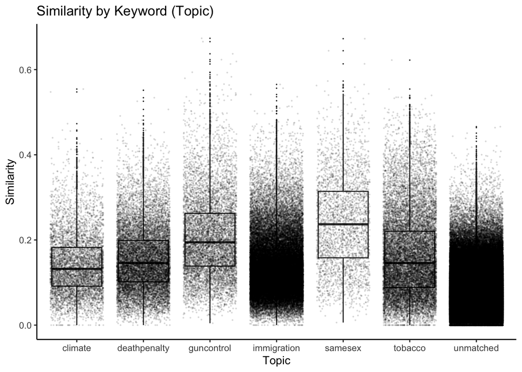

```r
# Dropping already matched
all_pairs_merge2 = subset(all_pairs_merge2, !is.na(similarity))

# Plot
ggplot(all_pairs_merge2, aes(keyword_pair, similarity)) +
    geom_boxplot(outlier.size = 0) +
    geom_jitter(aes(keyword_pair, similarity),
                position = position_jitter(width = 0.4, height = 0),
                alpha = 0.1, size = 0.2, show.legend = F) +
    theme(axis.text.x = element_text(angle = 45, vjust = 1, hjust = 1)) +
    xlab("Topic") + ylab("Similarity") +
    ggtitle("Similarity by Keyword (Topic)") +
    theme_classic()
```

```r
# mean similarity
aggregate(similarity ~ keyword_pair, data = all_pairs_merge2, mean)
```

| keyword_pair | similarity |
| --- | --- |
| climate | 0.14256 |
| deathpenalty | 0.15518 |
| guncontrol | 0.20682 |
| immigration | 0.13962 |
| samesex | 0.24069 |
| tobacco | 0.16246 |
| unmatched | 0.07233 |

The boxplots and mean similarity scores provide evidence that articles within a keyword topic are more similiar to those umatched. Articles concerning same sex marriage and gun control are most similiar to one another. The next step in such an analysis would be conducting appropriate statistical tests (e.g., t-test, ANOVA).

In closing, we want to emphasize the great utility of the `textreuse` package. While outside the scope of this class, it offers canned functions for pairwise comparisons as well as other text similarity approaches for large corpora, including minhashing and text alignment.

**Question 2 (BREAKOUT). Re-tokenize the news corpus but *leave* stopwords in the dfm. Calculate cosine dissimiliarity by group (source) and plot an updated dendrogram. What differences or similiarities do you observe? Why?**

**Question 3 (BREAKOUT). Subset the news corpus into a single topic (keyword) that interests you. Using cosine similarity, examine whether *articles* produced by the same source are more or less similar than *articles* produced by different sources. What do you find?**